# Programming in R (OC+DL): Solution for exam part 2 (15/01/2024)

JUAN VANEGAS (2023/2024)

# Part 1: the `real_data_GDI` data

In this part of the exam, the questions are focused on the `real_data_GDI` dataset which is a part of the `genderstat` R package. To access the data you need to install the package. More information can be found on https://cran.r-project.org/web/packages/genderstat/index.html. Use the code below to access the data.

```r
library(genderstat)
data("real_data_GDI")
names(real_data_GDI)
```

```
## [1] "country"                "female_life_expectancy" "male_life_expectancy"
## [4] "female_mean_schooling"  "male_mean_schooling"    "female_gni_per_capita"
## [7] "male_gni_per_capita"
```

## Question 1

### Solution 1.1

```r
gdi <- real_data_GDI %>%
  filter(complete.cases(.))
paste(nrow(gdi), "observations")
```

```
## [1] "174 observations"
```

2. Create a new data, `gdi2`, by transforming the `gdi` dataset from Q1.1 into a dataset for which the information for each country appears in two lines: one for female and one for male, see the first few lines below. For example, as shown below, for Afghanistan, the first line contains information about female and the second line information about male.

### Solution 1.2

```r
# TODO pivot instead
genders <- c("male", "female")
female_data <- gdi %>%
  mutate(gender="female") %>%
  mutate(gender=factor(gender, levels=genders)) %>%
  select(gender, country, female_life_expectancy, female_mean_schooling, female_gni_per_capita) %>%
  rename(life_expectancy = female_life_expectancy) %>%
  rename(mean_schooling = female_mean_schooling) %>%
  rename(gni_per_capita = female_gni_per_capita)

male_data <- gdi %>%
  mutate(gender="male") %>%
  mutate(gender=factor(gender, levels=genders)) %>%
  select(gender, country, male_life_expectancy, male_mean_schooling, male_gni_per_capita) %>%
  rename(life_expectancy = male_life_expectancy) %>%
  rename(mean_schooling = male_mean_schooling) %>%
  rename(gni_per_capita = male_gni_per_capita)

gdi2 <- bind_rows(female_data, male_data)  %>%
  arrange(country) %>%
  select(country, gender, life_expectancy, mean_schooling, gni_per_capita)
head(gdi2)
```

```
##       country gender life_expectancy mean_schooling gni_per_capita
## 1 Afghanistan female            65.3            2.3            533
## 2 Afghanistan   male            58.9            3.4           3089
## 3     Albania female            79.2           11.7          11637
## 4     Albania   male            74.1           10.9          16630
## 5     Algeria female            78.0            7.7           3550
## 6     Algeria   male            74.9            8.4          17787
```

### Solution 1.3

```r
gdi3 <- gdi2 %>%
  pivot_longer(cols = c(life_expectancy, mean_schooling, gni_per_capita), names_to = "Measurement", values_to = "Values")
head(gdi3)
```

```
## # A tibble: 6 × 4
##   country     gender Measurement     Values
##   <chr>       <fct>  <chr>            <dbl>
## 1 Afghanistan female life_expectancy   65.3
## 2 Afghanistan female mean_schooling     2.3
## 3 Afghanistan female gni_per_capita   533
## 4 Afghanistan male   life_expectancy   58.9
## 5 Afghanistan male   mean_schooling     3.4
## 6 Afghanistan male   gni_per_capita  3089
```

4. For the new dataset `gdi3`, replace the “_” in column `Measurement` by ” ” (space), as shown below.

### Solution 1.4

```r
gdi3 <- gdi3 %>%
  mutate(Measurement = str_replace(Measurement, "_", " "))
head(gdi3)
```

```
## # A tibble: 6 × 4
##   country     gender Measurement     Values
##   <chr>       <fct>  <chr>            <dbl>
## 1 Afghanistan female life expectancy   65.3
## 2 Afghanistan female mean schooling     2.3
## 3 Afghanistan female gni per_capita   533
## 4 Afghanistan male   life expectancy   58.9
## 5 Afghanistan male   mean schooling     3.4
## 6 Afghanistan male   gni per_capita  3089
```

## Question 2

1. In this question, we use the `gdi` dataset created in Q1.1. Produce Figure 2.1 which presents a figure with **two** separate plots in one column and two rows.

### Solution 2.1

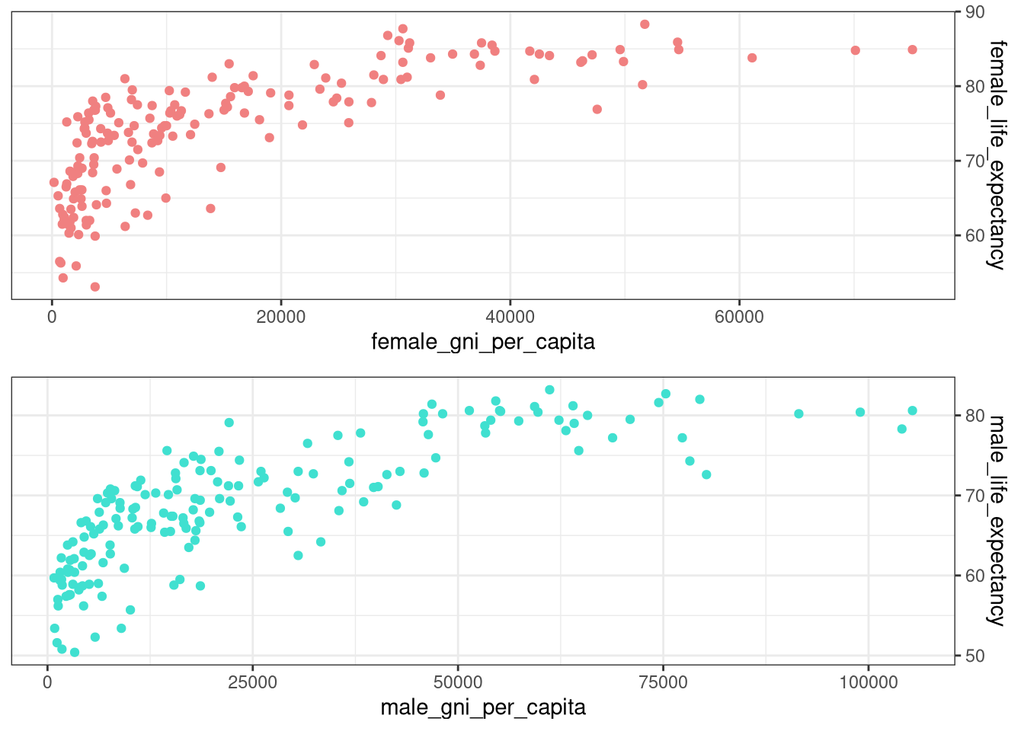

```r
# ggplot dots in red and the y line should be on the right
p1 <- ggplot(gdi, aes(x=female_gni_per_capita, y = female_life_expectancy)) +
  geom_point(color="lightcoral") +
  theme_bw() +
  scale_y_continuous(position="right")
p2 <- ggplot(gdi, aes(male_gni_per_capita, y = male_life_expectancy)) +
  geom_point(color="turquoise") +
  scale_y_continuous(position="right") +
  theme_bw()
gridExtra::grid.arrange(p1, p2, ncol=1)
```

2. In this question, use the `gdi2` dataset and produce Figure 2.2.

### Solution 2.2

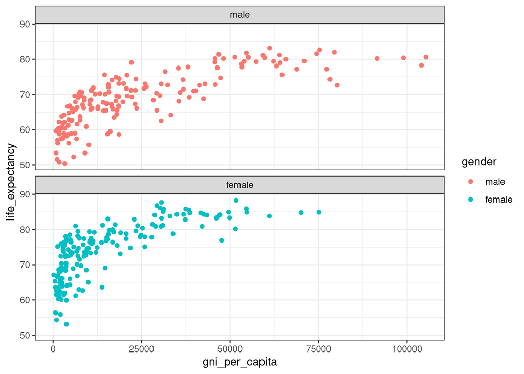

```r
ggplot(gdi2, aes(x=gni_per_capita, y = life_expectancy, color = gender)) +
  geom_point() +
  theme_bw() +
  facet_wrap(~gender, ncol=1)
```

## Question 3

1. Use the `gdi` dataset that was created in Q1.1. Create a new variable `diff` which is the difference between female and male life expectancy and add this variable to the dataset.

### Solution 3.1

```r
gdi <- gdi %>%
  mutate(diff = female_life_expectancy - male_life_expectancy)
head(gdi)
```

```
##       country female_life_expectancy male_life_expectancy female_mean_schooling
## 1 Afghanistan                   65.3                 58.9                   2.3
## 2     Albania                   79.2                 74.1                  11.7
## 3     Algeria                   78.0                 74.9                   7.7
## 4      Angola                   64.3                 59.0                   4.2
## 5   Argentina                   78.6                 72.2                  11.4
## 6     Armenia                   77.4                 66.6                  11.3
##   male_mean_schooling female_gni_per_capita male_gni_per_capita diff
## 1                 3.4                   533                3089  6.4
## 2                10.9                 11637               16630  5.1
## 3                 8.4                  3550               17787  3.1
## 4                 6.9                  4751                6197  5.3
## 5                10.9                 15581               26376  6.4
## 6                11.3                  8736               18558 10.8
```

2. Create a summary table of the minimum, maximum, mean and the $25\%$ quantile of the variable `diff`. Create a new R object, `q25`, which is equal to the $25\%$ quantile of the variable `diff` and print it.

### Solution 3.2

```r
data.frame(min = min(gdi$diff), max = max(gdi$diff), mean = mean(gdi$diff), q25 = quantile(gdi$diff, 0.25))
```

```
##     min  max     mean   q25
## 25% 0.8 10.8 5.366667 4.025
```

```r
q25 <- quantile(gdi$diff, 0.25)
q25
```

```
##   25%
## 4.025
```

3. Create a new dataset, `gdi_new`, that consists of countries with the life expectancy gap between gender (the variable `diff`) less than its `q25`. How many countries are included in the new data?

### Solution 3.3

```r
gdi_new <- gdi %>%
  filter(diff < q25)
head(gdi_new)
```

```
##      country female_life_expectancy male_life_expectancy female_mean_schooling
## 1    Algeria                   78.0                 74.9                   7.7
## 2  Australia                   85.8                 83.2                  12.8
## 3    Bahrain                   80.0                 77.8                  10.8
## 4 Bangladesh                   74.3                 70.6                   6.8
## 5   Barbados                   79.4                 75.6                  10.3
## 6      Benin                   61.4                 58.2                   3.3
##   male_mean_schooling female_gni_per_capita male_gni_per_capita diff
## 1                 8.4                  3550               17787  3.1
## 2                12.6                 37486               61161  2.6
## 3                11.2                 16786               53359  2.2
## 4                 8.0                  2811                8176  3.7
## 5                 9.1                 10235               14555  3.8
## 6                 5.4                  2998                3819  3.2
```

4. Select 10 countries with the largest `female_gni_per_capita` from the new data created in Q3.2. Produce Figure 3.1.

### Solution 3.4

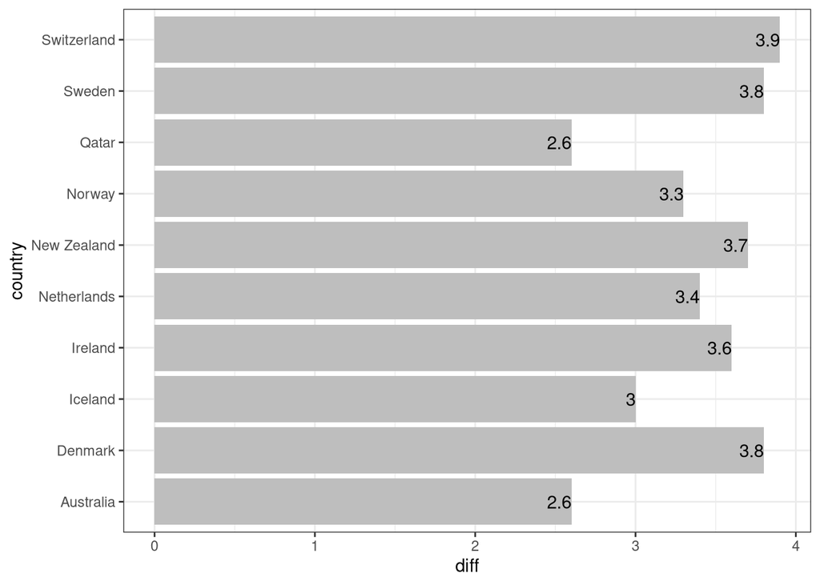

```r
q3_4.df <- gdi_new %>%
  arrange(-female_gni_per_capita) %>%
  head(10)
ggplot(q3_4.df, aes(x=country, y=diff)) +
  geom_col(fill="grey") +
  theme_bw() +
  geom_text(aes(label = round(diff, 2)), hjust = 1, color = "black") +
  coord_flip()
```

5. Show the countries with `female_life_expectancy` higher than 85 in different colours as seen in Figure 3.2.

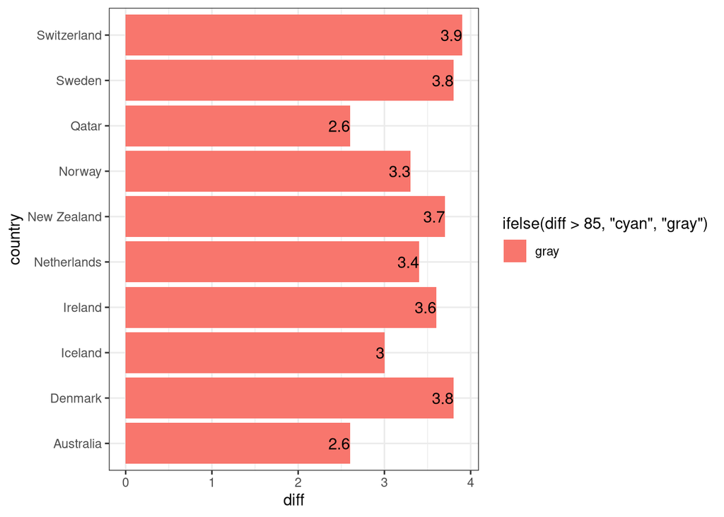

```r
# todo fix
ggplot(q3_4.df, aes(x=country, y=diff)) +
  geom_col(aes(fill = ifelse(diff > 85, "cyan", "gray"))) +
  theme_bw() +
  geom_text(aes(label = round(diff, 2)), hjust = 1, color = "black") +
  coord_flip()
```

# Part 2 : the `flying` data

For the analysis of this part we use the `flying` data which is a part of the R package `dropout`. This is a modified version of the Flying Etiquette Survey data. More information can be found in https://CRAN.R-project.org/package=dropout. The code below can be used to access the data

```r
library(dropout)
data("flying")
names(flying)
```

```
##  [1] "respondent_id"               "travel_frequency"
##  [3] "seat_recline"                "height"
##  [5] "children_under_18"           "two_armrests"
##  [7] "middle_armrest"              "window_shade"
##  [9] "moving_to_unsold_seat"       "talking_to_seatmate"
## [11] "getting_up_on_6_hour_flight" "obligation_to_reclined_seat"
## [13] "recline_seat_rudeness"       "eliminate_reclining_seats"
## [15] "switch_for_friends"          "switch_for_family"
## [17] "wake_passenger_bathroom"     "wake_passenger_walk"
## [19] "baby_on_plane"               "unruly_children"
## [21] "electronics_violation"       "smoking_violation"
## [23] "gender"                      "age"
## [25] "household_income"            "education"
## [27] "location_census_region"      "survey_type"
```

## Question 4

For this question, use `flying` data without the missing values.

1. Calculate the frequency and the percentage of each response to the question “in a row of two seats, who should get to use the middle arm rest?” (variable `middle_armrest`) and define the dataframe shown below (note that the dataframe shows the different categories of the question, the number of answers and the percentage).

### Solution 4.1

```r
flying <- flying %>%
  filter(complete.cases(.))
q4_1.df <- flying %>%
  filter(!is.na(middle_armrest)) %>%
  group_by(middle_armrest) %>%
  summarise(n = n()) %>%
  mutate(percentage = round(n/sum(n)*100, 2))
q4_1.df
```

```
## # A tibble: 5 × 3
##   middle_armrest                                   n percentage
##   <chr>                                        <int>      <dbl>
## 1 Other (please specify)                          32       4.73
## 2 The arm rests should be shared                 471      69.6
## 3 The person by the window                        26       3.84
## 4 The person in aisle                             49       7.24
## 5 Whoever puts their arm on the arm rest first    99      14.6
```

2. Produce Figure 4.1.

### Solution 4.2

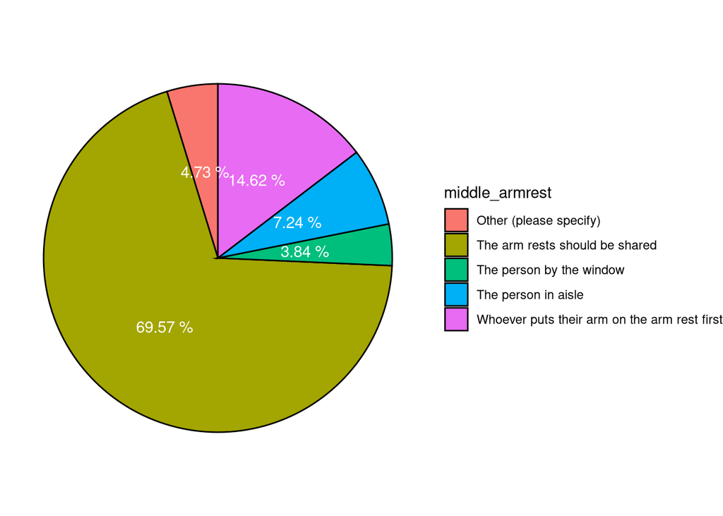

```r
ggplot(q4_1.df, aes(x = "", y = n, fill = middle_armrest, label = paste(percentage, "%"))) +
  geom_col(width = 1, color = "black") +
  geom_text(position = position_stack(vjust = 0.5), color="white") +
  coord_polar(theta = "y", direction = 1) +
  theme_void()
```

3. Produce Figure 4.2.

### Solution 4.3

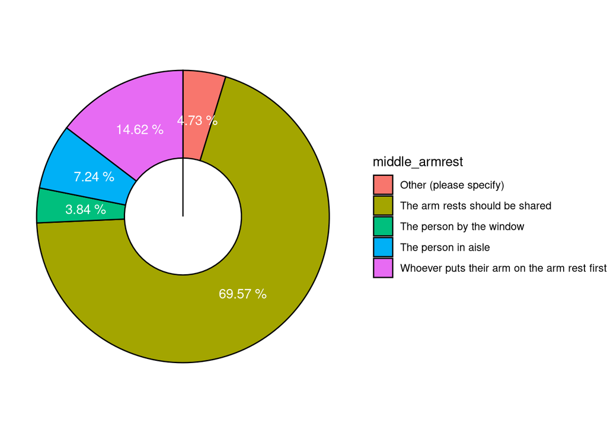

```r
# generate the same as before but with the center not filled

ggplot(q4_1.df, aes(x = "", y = n, fill = middle_armrest, label = paste(percentage, "%"))) +
  geom_col(width = 1, color = "black") +
  geom_text(position = position_stack(vjust = 0.5), color="white") +
  coord_polar(theta = "y", direction = -1) +
  theme_void() +
  annotate("rect", xmin = 0, xmax = 0.6, ymin = 0, ymax = Inf, fill = "white", alpha = 1, color="black")
```

## Question 5

1. For this question, use `flying` data without the missing values. We focus on the variables `middle_armrest` and `age`. Produce the table shown below, which shows the frequency of each response to the question “in a row of two seats, who should get to use the middle arm rest?” across the age of the respondents.

### Solution 5.1

```r
q5_1.df <- flying %>%
  group_by(middle_armrest, age) %>%
  summarise(n = n(), .groups = "drop") %>%
  pivot_wider(names_from = age, values_from = n)
q5_1.df
```

```
## # A tibble: 5 × 5
##   middle_armrest                               `18-29` `30-44` `45-60` `> 60`
##   <chr>                                          <int>   <int>   <int>  <int>
## 1 Other (please specify)                             7      12       7      6
## 2 The arm rests should be shared                    81     115     144    131
## 3 The person by the window                           4       6      12      4
## 4 The person in aisle                               20      14       8      7
## 5 Whoever puts their arm on the arm rest first      25      26      32     16
```

2. Use a chi-square test to test the hypothesis `middle_armrest` and `age` are independent.

### Solution 5.2

```r
chisq.test(q5_1.df[,2:5])
```

```
##
##  Pearson's Chi-squared test
##
## data:  q5_1.df[, 2:5]
## X-squared = 30.909, df = 12, p-value = 0.002034
```

# Part 3: the external `opt` datasets (Q6-Q8)

In this section, we focus on 3 **external** Excel files that contain data of Obstetrics and Periodontal Therapy.The external files are avilable online in BB. Description of each variable can be seen in https://rdrr.io/cran/medicaldata/man/opt.html. To access the datasets `opt1`, `opt2` and `opt3`, these Excel files first need to be imported to R. This means that you need to read these external files to R. The excel files are available in BB. If you do not know how to do it you can look at https://datatofish.com/import-excel-r/.

The datasets `opt1` and `opt2` contain the same information about different trial participants (i.e., different subjects), while the dataset `opt3` contains additional information about the medical condition (disease) of the participants. Variables names for all datasets are given below.

```r
opt1 <- read_excel("opt1.xlsx")
opt2 <- read_excel("opt2.xlsx")
opt3 <- read_excel("opt3.xlsx")
```

```r
names(opt1)
```

```
## [1] "PID"         "Clinic"      "Group"       "Age"         "Education"
## [6] "BMI"         "Birthweight"
```

```r
names(opt2)
```

```
## [1] "Participant_ID" "Clinic"         "Group"          "Age"
## [5] "Education"      "BMI"            "Birthweight"
```

```r
names(opt3)
```

```
## [1] "participantID" "clinic"        "Hypertension"  "Diabetes"
```